# 4.1

# HomeWork 4.1

In this homework we will use the software GeNIe for building and querying graphicals models for decision making. Our aim is to improve the therapeutic iter patients affected by the Non-Hodgkin lymphoma are going through, enhancing their chances to survive.

## Task 1

We have to predict for each patient which is the best treatment for their Non-Hodgkin lymphoma of the stomach. For each patient we have the following informations:

- Age, that in the pre-built network on GeNIe is given in 5/10 years classes
- Particular stage of the disease
- Histological classi???cation, which stands for the assessment by a pathologist of tumour tissue obtained from a biopsy
- Whether the disease is bulky or non-bulky
- Whether is present or absent the bacterium Helicobacter pylori
- The gastric clinical condition the patient suffers from

```r
patiens=data.frame(rbind(
c(61,"I","high","nonbulky","absent","perforation"),
c(39,"I","high","bulky","absent","none"),
c(64,"I","low","nonbulky","present","none"),
c(63,"II1","high","nonbulky","present","obstruction"),
c(77,"II1","low","nonbulky","present","none"),
c(82,"II1","high","bulky","absent","none"),
c(46,"II1","high","nonbulky","present","hemorrhage"),
c(60,"I","high","nonbulky","present","none"),
c(47,"I","high","bulky","present","none"),
c(67,"IV","high","nonbulky","absent","none"),
c(73,"IV","high","bulky","absent","none")),
stringsAsFactors= T
)

colnames(patiens)<-c("Age","ClinicalStage","HistClassification","BulkyDisease","HelicobacterPylori","GastrClinCond")

patiens
```

```
##    Age ClinicalStage HistClassification BulkyDisease HelicobacterPylori
## 1   61             I               high     nonbulky             absent
## 2   39             I               high        bulky             absent
## 3   64             I                low     nonbulky            present
## 4   63           II1               high     nonbulky            present
## 5   77           II1                low     nonbulky            present
## 6   82           II1               high        bulky             absent
## 7   46           II1               high     nonbulky            present
## 8   60             I               high     nonbulky            present
## 9   47             I               high        bulky            present
## 10  67            IV               high     nonbulky             absent
## 11  73            IV               high        bulky             absent
##    GastrClinCond
## 1    perforation
## 2           none
## 3           none
## 4    obstruction
## 5           none
## 6           none
## 7     hemorrhage
## 8           none
## 9           none
## 10          none
## 11          none
```

In order to suggest the best cures, we used the software GeNIe. Inside the software we tried, for every patient’s attributes, the twelve different curative possibilities given. As measure of the treatment’s succes we have watched firstly at *5YearsResult* and then at *PostTreatmentResult*. Our aim has been to ensure the patient the best possibilities to survive, regardingless other importants aspects than can be evaluated in such cases(e.g. patient’s psychological wellbeing)

```r
suggestedtreatment=data.frame(rbind(
  c("none","chemio",0.67,0.86),
  c("palliative","both",0.27,0.80),
  c("palliative","both",0.39,0.95),
  c("palliative","both",0.29,0.85),
  c("palliative","both",0.37,0.90),
  c("palliative","both",0.23,0.75),
  c("palliative","both",0.43,0.85),
  c("palliative","both",0.33,0.90),
  c("palliative","both",0.27,0.80),
  c("palliative","both",0.18,0.65),
  c("palliative","both",0.07,0.45)
))
colnames(suggestedtreatment)<-c("Surgery","ctrtSchedule","5YearsResult","PostTreatmentResult")

suggestedtreatment
```

```
##       Surgery ctrtSchedule 5YearsResult PostTreatmentResult
## 1        none       chemio         0.67                0.86
## 2  palliative         both         0.27                 0.8
## 3  palliative         both         0.39                0.95
## 4  palliative         both         0.29                0.85
## 5  palliative         both         0.37                 0.9
## 6  palliative         both         0.23                0.75
## 7  palliative         both         0.43                0.85
## 8  palliative         both         0.33                 0.9
## 9  palliative         both         0.27                 0.8
## 10 palliative         both         0.18                0.65
## 11 palliative         both         0.07                0.45
```

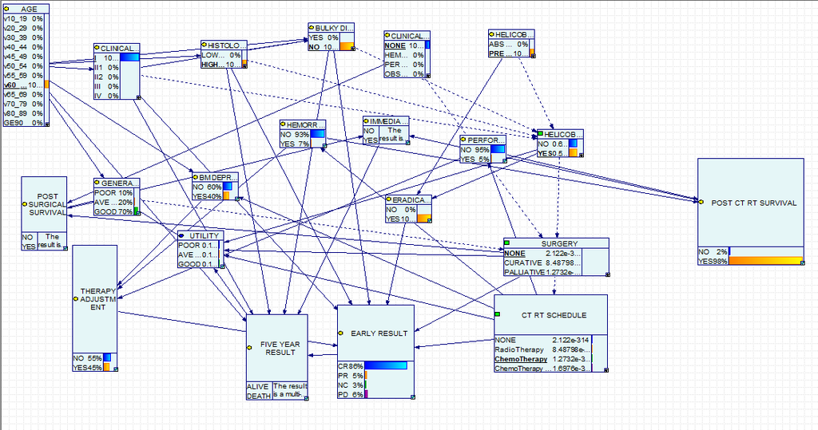

Screenshot of GeNIe